# Cars4U Project 3 Brandy Murray

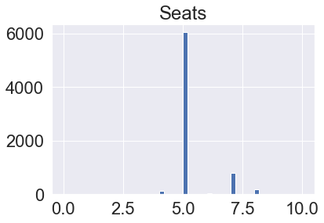

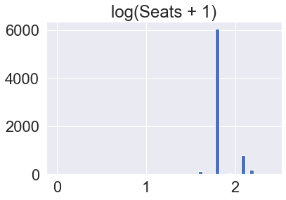

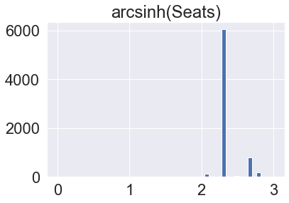

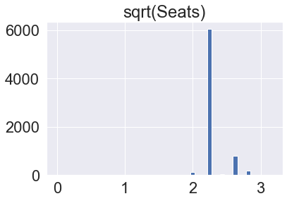

```python
plt.hist(df["Seats"], 50)
plt.title("Seats")
plt.show()
plt.hist(np.log(df["Seats"] + 1), 50)
plt.title("log(Seats + 1)")
plt.show()
plt.hist(np.arcsinh(df["Seats"]), 50)
plt.title("arcsinh(Seats)")
plt.show()
plt.hist(np.sqrt(df["Seats"]), 50)
plt.title("sqrt(Seats)")
plt.show()
```

The Seats variable is difficult because it almost should be considered a category. This futher proves that the number of seats is not being used for a numerical purpose, but rather for informational purposes.

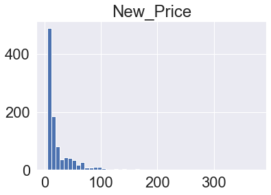

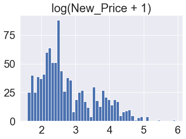

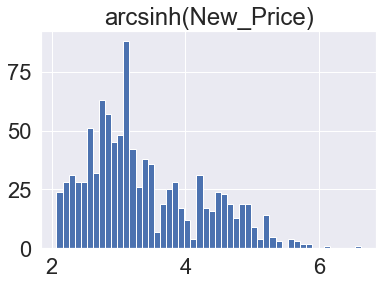

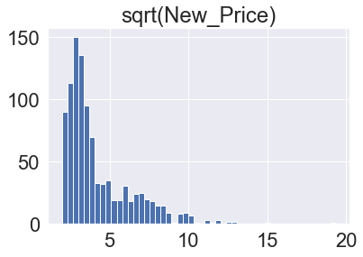

```python
plt.hist(df["New_Price"], 50)
plt.title("New_Price")
plt.show()
plt.hist(np.log(df["New_Price"] + 1), 50)
plt.title("log(New_Price + 1)")
plt.show()
plt.hist(np.arcsinh(df["New_Price"]), 50)
plt.title("arcsinh(New_Price)")
plt.show()
plt.hist(np.sqrt(df["New_Price"]), 50)
plt.title("sqrt(New_Price)")
plt.show()
```

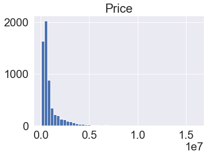

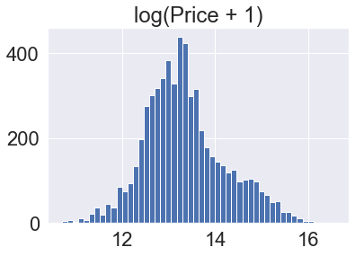

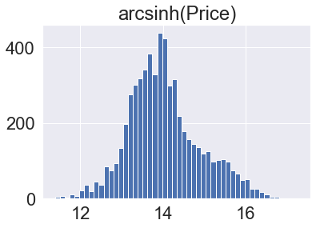

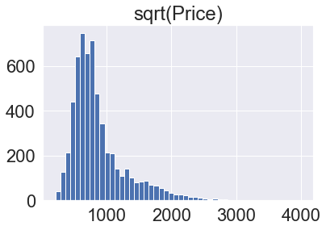

```python
plt.hist(df["Price"], 50)
plt.title("Price")
plt.show()
plt.hist(np.log(df["Price"] + 1), 50)
plt.title("log(Price + 1)")
plt.show()
plt.hist(np.arcsinh(df["Price"]), 50)
plt.title("arcsinh(Price)")
plt.show()
plt.hist(np.sqrt(df["Price"]), 50)
plt.title("sqrt(Price)")
plt.show()
```

Using the arcsinh again made the curve really expand into a more normal looking distribution. The tail is slightly longer on the right side cause a small amount of skewedness. However, this looks much better than the origibal histogram.

Bivariate Analysis

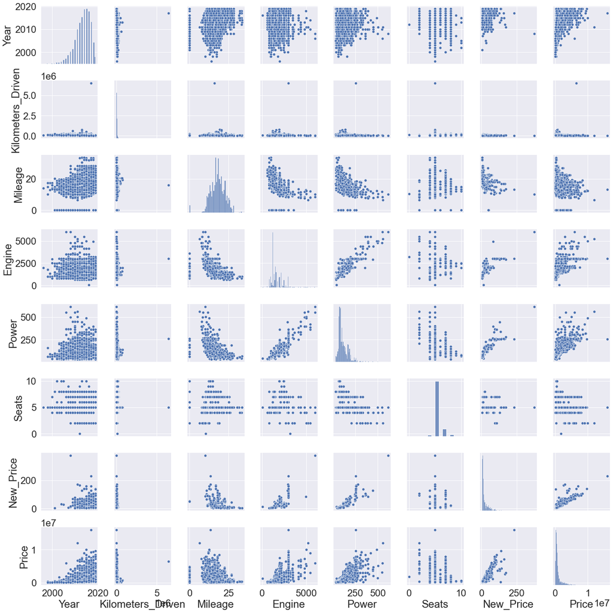

```python
sns.pairplot(data=df)
```

```python
df.corr()
```

|  | Year | Kilometers_Driven | Mileage | Engine | Power | Seats | New_Price | Price |
| --- | --- | --- | --- | --- | --- | --- | --- | --- |
| Year | 1.000000 | -0.187859 | 0.322463 | -0.054693 | 0.013432 | 0.008216 | -0.058798 | 0.305327 |
| Kilometers_Driven | -0.187859 | 1.000000 | -0.069122 | 0.094818 | 0.030164 | 0.090221 | -0.008221 | -0.011493 |
| Mileage | 0.322463 | -0.069122 | 1.000000 | -0.593569 | -0.531771 | -0.310632 | -0.378327 | -0.306593 |
| Engine | -0.054693 | 0.094818 | -0.593569 | 1.000000 | 0.859771 | 0.399262 | 0.735981 | 0.658354 |
| Power | 0.013432 | 0.030164 | -0.531771 | 0.859771 | 1.000000 | 0.095905 | 0.877708 | 0.772566 |
| Seats | 0.008216 | 0.090221 | -0.310632 | 0.399262 | 0.095905 | 1.000000 | -0.019459 | 0.052225 |
| New_Price | -0.058798 | -0.008221 | -0.378327 | 0.735981 | 0.877708 | -0.019459 | 1.000000 | 0.871847 |
| Price | 0.305327 | -0.011493 | -0.306593 | 0.658354 | 0.772566 | 0.052225 | 0.871847 | 1.000000 |

```python
df.corr()["Price"]
df.corr().sort_values(by="Price", ascending=False)["Price"]
```

```
Price                1.000000
New_Price            0.871847
Power                0.772566
Engine               0.658354
Year                 0.305327
Seats                0.052225
Kilometers_Driven   -0.011493
Mileage             -0.306593
Name: Price, dtype: float64
```

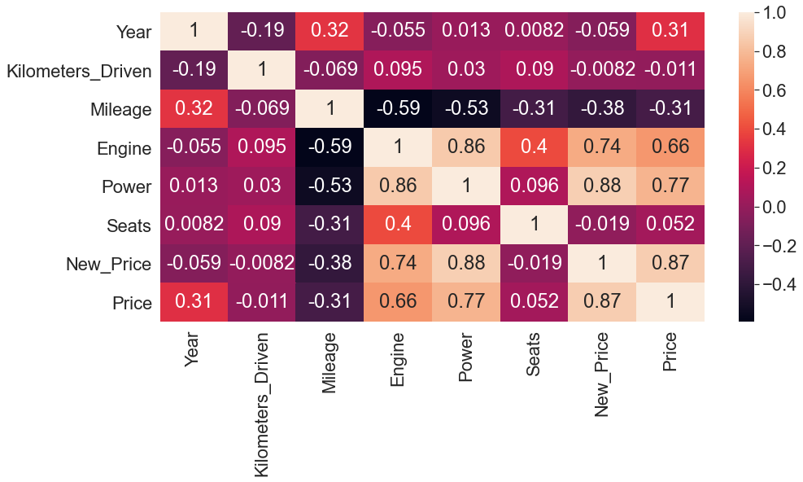

```python
plt.figure(figsize=(15, 7))
sns.heatmap(df.corr(), annot=True)
```

I feel comfortable dropping New_Price at this point because is so tightly correlated with both Power and Price. We were going to have to address the high amount of NaN values but the tight correlation with other variables means we won't miss the affects of the data we have.

```python
df.drop("New_Price", axis=1, inplace=True)
```

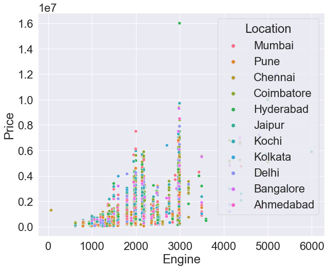

```python
plt.figure(figsize=(10, 8))
sns.scatterplot(data=df, x="Engine", y="Price", hue="Location")
```

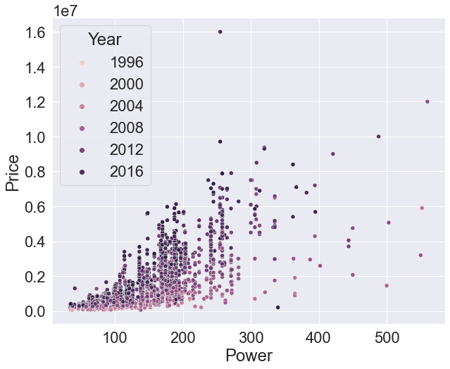

```python
plt.figure(figsize=(10, 8))
sns.scatterplot(data=df, x="Power", y="Price", hue="Year")
```

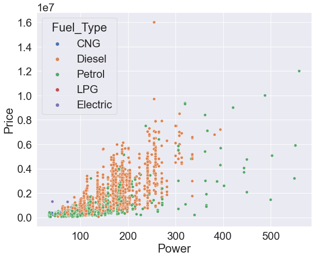

```python
plt.figure(figsize=(10, 8))
sns.scatterplot(data=df, x="Power", y="Price", hue="Fuel_Type")
```

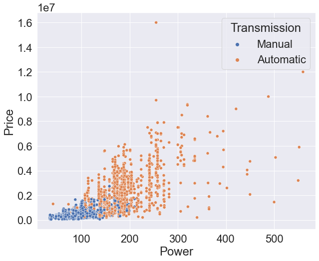

```python
plt.figure(figsize=(10, 8))
sns.scatterplot(data=df, x="Power", y="Price", hue="Transmission")
```

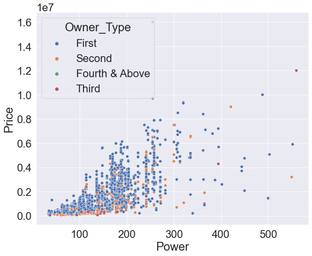

```python
plt.figure(figsize=(10, 8))
sns.scatterplot(data=df, x="Power", y="Price", hue="Owner_Type")
```

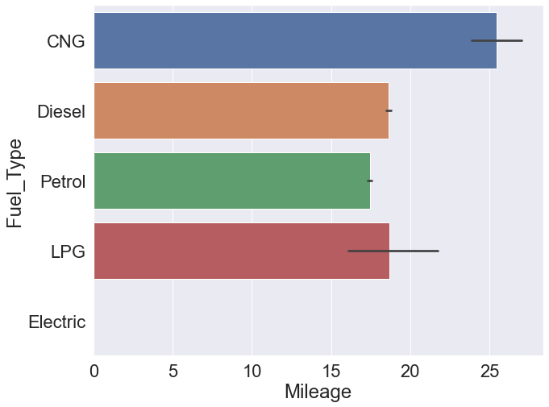

```python
plt.figure(figsize=(10, 8))
sns.barplot(data=df, x="Mileage", y="Fuel_Type")
```

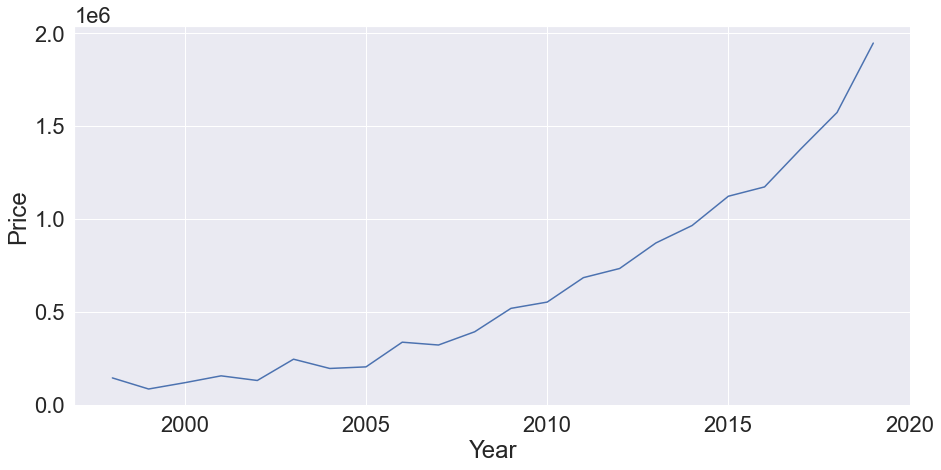

```python
plt.figure(figsize=(15, 7))
sns.lineplot(x="Year", y="Price", data=df, ci=None)
```

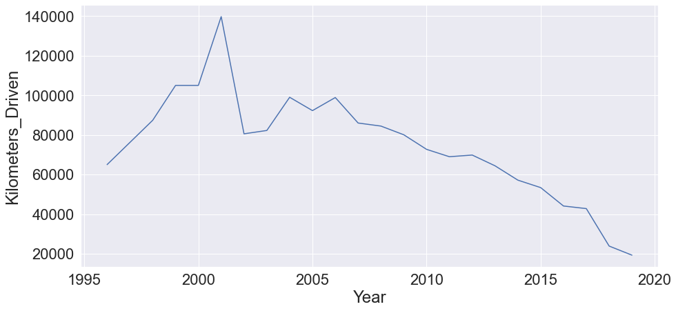

```python
plt.figure(figsize=(15, 7))
sns.lineplot(x="Year", y="Kilometers_Driven", data=df, ci=None)
```

5. Data Pre-Processing & Feature Engineering

Earlier I did a scatterplot by location and was not able to receive much insight from it because there are quite a few cities. Therefore, I wanted to develop a way to group the cities into a more insightful meaning. From Google Maps I took a screenshot of India and then split India into four quadrants. After locating each city and determining the area of the map each city resides, I created a dictionary that I then used the map function to apply the dictionary the Location column of the dataframe.

How I split the cities.

[figure not shown]

```python
# Getting a list of the cities in the dataframe
df["Location"].value_counts(dropna=False)
```

```
Mumbai        949
Hyderabad     876
Kochi         772
Coimbatore    772
Pune          765
Delhi         660
Kolkata       654
Chennai       591
Jaipur        499
Bangalore     440
Ahmedabad     275
Name: Location, dtype: int64
```

```python
# Creating the dictionary associating the cities with the region
Region_Dict = {
    "Delhi": "Northwest",
    "Jaipur": "Northwest",
    "Ahmedabad": "Northwest",
    "Kolkata": "Northeast",
    "Mumbai": "Southwest",
    "Kochi": "Southwest",
    "Coimbatore": "Southwest",
    "Pune": "Southwest",
    "Bangalore": "Southwest",
    "Hyderabad": "Southeast",
    "Chennai": "Southeast",
}
Region_Dict
```

```
{'Delhi': 'Northwest',
 'Jaipur': 'Northwest',
 'Ahmedabad': 'Northwest',
 'Kolkata': 'Northeast',
 'Mumbai': 'Southwest',
 'Kochi': 'Southwest',
 'Coimbatore': 'Southwest',
 'Pune': 'Southwest',
 'Bangalore': 'Southwest',
 'Hyderabad': 'Southeast',
 'Chennai': 'Southeast'}
```

```python
# Creating the new Region column by using the map function
df["Region"] = df["Location"].map(Region_Dict)
```

```python
df.head()
```

|  | Location | Year | Kilometers_Driven | Fuel_Type | Transmission | Owner_Type | Mileage | Engine | Power | Seats | Price | Brand | Model | Region |
| --- | --- | --- | --- | --- | --- | --- | --- | --- | --- | --- | --- | --- | --- | --- |
| 0 | Mumbai | 2010 | 72000 | CNG | Manual | First | 26.60 | 998.0 | 58.16 | 5.0 | 175000.0 | Maruti | Wagon R LXI CNG | Southwest |
| 1 | Pune | 2015 | 41000 | Diesel | Manual | First | 19.67 | 1582.0 | 126.20 | 5.0 | 1250000.0 | Hyundai | Creta 1.6 CRDi SX Option | Southwest |
| 2 | Chennai | 2011 | 46000 | Petrol | Manual | First | 18.20 | 1199.0 | 88.70 | 5.0 | 450000.0 | Honda | Jazz V | Southeast |
| 3 | Chennai | 2012 | 87000 | Diesel | Manual | First | 20.77 | 1248.0 | 88.76 | 7.0 | 600000.0 | Maruti | Ertiga VDI | Southeast |
| 4 | Coimbatore | 2013 | 40670 | Diesel | Automatic | Second | 15.20 | 1968.0 | 140.80 | 5.0 | 1774000.0 | Audi | A4 New 2.0 TDI Multitronic | Southwest |

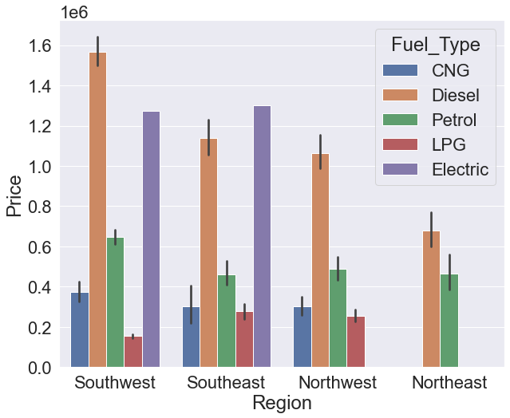

```python
plt.figure(figsize=(10, 8))
sns.barplot(data=df, x="Region", y="Price", hue="Fuel_Type")
```

```python
def count_on_bar(data, z):
    """
    plot
    feature: categorical feature
    the function won't work if a column is passed in hue parameter
    """

    total = len(data[z])  # length of the column
    plt.figure(figsize=(15, 5))
    plt.xticks(rotation=45)
    ax = sns.countplot(data=data, x=z, palette="Paired")
    for p in ax.patches:
        percentage = p.get_height()  # count of each class of the category
        x = p.get_x() + p.get_width() / total + 0.2  # width of the plot
        y = p.get_y() + p.get_height()  # height of the plot

        ax.annotate(percentage, (x, y), size=12)  # annotate the percentage
    plt.show()  # show the plot
```

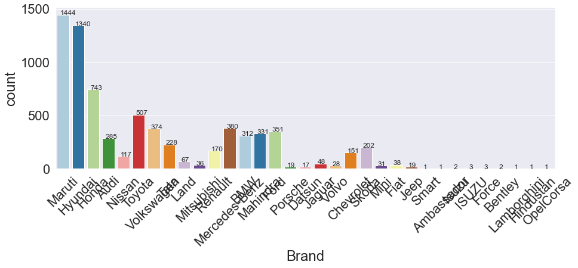

```python
count_on_bar(df, "Brand")
```

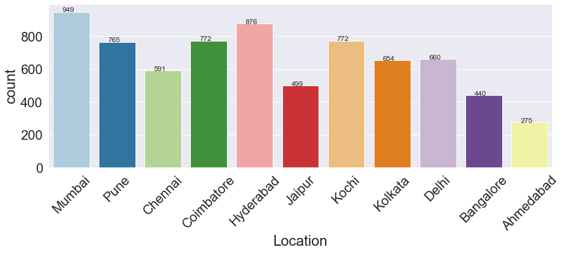

```python
count_on_bar(df, "Location")
```

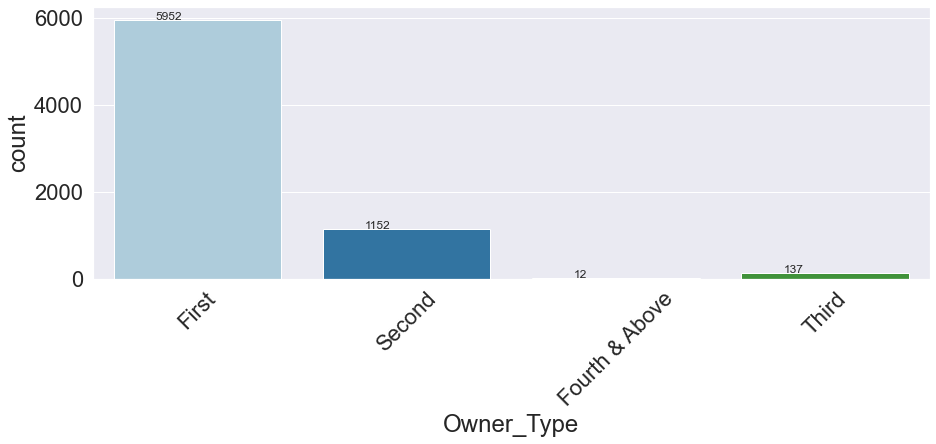

```python
count_on_bar(df, "Owner_Type")
```

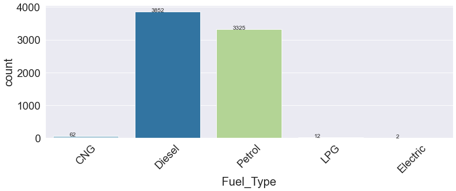

```python
count_on_bar(df, "Fuel_Type")
```

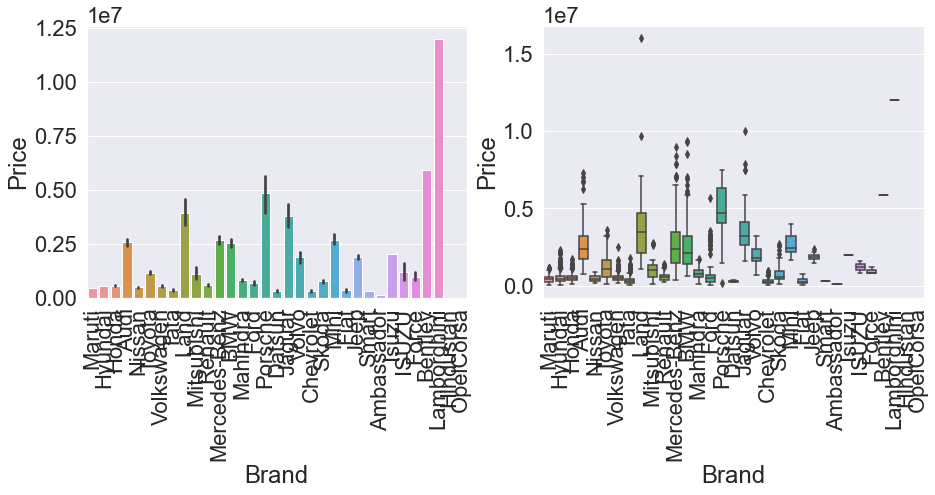

```python
plt.figure(figsize=(15, 5))

plt.subplot(1, 2, 1)
sns.barplot(data=df, y="Price", x="Brand")
plt.xticks(rotation=90)

plt.subplot(1, 2, 2)
sns.boxplot(data=df, y="Price", x="Brand")
plt.xticks(rotation=90)

plt.show()
```

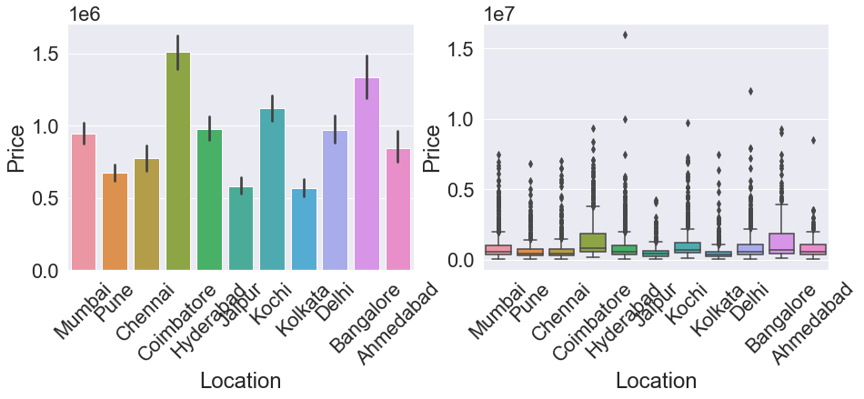

```python
plt.figure(figsize=(15, 5))

plt.subplot(1, 2, 1)
sns.barplot(data=df, y="Price", x="Location")
plt.xticks(rotation=45)

plt.subplot(1, 2, 2)
sns.boxplot(data=df, y="Price", x="Location")
plt.xticks(rotation=45)

plt.show()
```

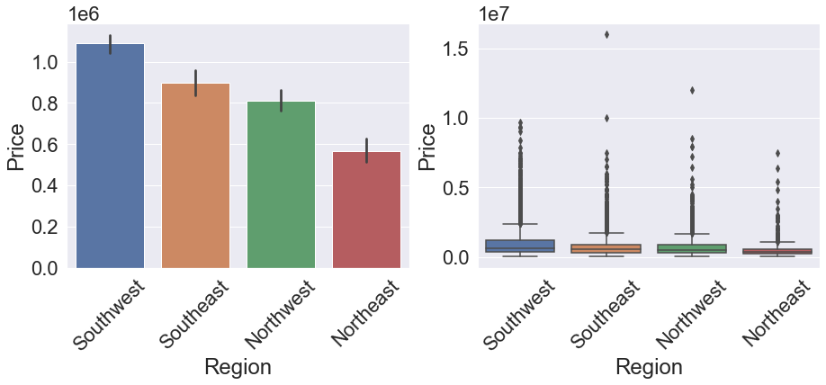

```python
plt.figure(figsize=(15, 5))

plt.subplot(1, 2, 1)
sns.barplot(data=df, y="Price", x="Region")
plt.xticks(rotation=45)

plt.subplot(1, 2, 2)
sns.boxplot(data=df, y="Price", x="Region")
plt.xticks(rotation=45)

plt.show()
```

Making Categoricals into Categorical Types

```python
df.head()
```

|  | Location | Year | Kilometers_Driven | Fuel_Type | Transmission | Owner_Type | Mileage | Engine | Power | Seats | Price | Brand | Model | Region |
| --- | --- | --- | --- | --- | --- | --- | --- | --- | --- | --- | --- | --- | --- | --- |
| 0 | Mumbai | 2010 | 72000 | CNG | Manual | First | 26.60 | 998.0 | 58.16 | 5.0 | 175000.0 | Maruti | Wagon R LXI CNG | Southwest |
| 1 | Pune | 2015 | 41000 | Diesel | Manual | First | 19.67 | 1582.0 | 126.20 | 5.0 | 1250000.0 | Hyundai | Creta 1.6 CRDi SX Option | Southwest |
| 2 | Chennai | 2011 | 46000 | Petrol | Manual | First | 18.20 | 1199.0 | 88.70 | 5.0 | 450000.0 | Honda | Jazz V | Southeast |
| 3 | Chennai | 2012 | 87000 | Diesel | Manual | First | 20.77 | 1248.0 | 88.76 | 7.0 | 600000.0 | Maruti | Ertiga VDI | Southeast |
| 4 | Coimbatore | 2013 | 40670 | Diesel | Automatic | Second | 15.20 | 1968.0 | 140.80 | 5.0 | 1774000.0 | Audi | A4 New 2.0 TDI Multitronic | Southwest |

```python
df.drop(["Model", "Brand", "Region", "Seats"], axis=1, inplace=True)
```

```python
df.info()
```

```
<class 'pandas.core.frame.DataFrame'>
RangeIndex: 7253 entries, 0 to 7252
Data columns (total 10 columns):
 #   Column             Non-Null Count  Dtype
---  ------             --------------  -----
 0   Location           7253 non-null   object
 1   Year               7253 non-null   int64
 2   Kilometers_Driven  7253 non-null   int64
 3   Fuel_Type          7253 non-null   object
 4   Transmission       7253 non-null   object
 5   Owner_Type         7253 non-null   object
 6   Mileage            7251 non-null   float64
 7   Engine             7207 non-null   float64
 8   Power              7078 non-null   float64
 9   Price              6019 non-null   float64
dtypes: float64(4), int64(2), object(4)
memory usage: 566.8+ KB
```

```python
cat_vars = [
    "Location",
    "Fuel_Type",
    "Transmission",
    "Owner_Type",
]
# the other categorical variables have lots of levels
# and I wouldn't dummy encode them as such

for colname in cat_vars:
    df[colname] = df[colname].astype("category")

df.info()
```

```
<class 'pandas.core.frame.DataFrame'>
RangeIndex: 7253 entries, 0 to 7252
Data columns (total 10 columns):
 #   Column             Non-Null Count  Dtype
---  ------             --------------  -----
 0   Location           7253 non-null   category
 1   Year               7253 non-null   int64
 2   Kilometers_Driven  7253 non-null   int64
 3   Fuel_Type          7253 non-null   category
 4   Transmission       7253 non-null   category
 5   Owner_Type         7253 non-null   category
 6   Mileage            7251 non-null   float64
 7   Engine             7207 non-null   float64
 8   Power              7078 non-null   float64
 9   Price              6019 non-null   float64
dtypes: category(4), float64(4), int64(2)
memory usage: 369.3 KB
```

Missing Values